# 1. Overview: The Impact of STR Density on Crime in New Orleans

**GitHub Pages Link:** ynv1002.github.io

**Team Members:** Yaniv Naggar & Nick Chvany

**Data Sets**

1. Short-Term Rental License Applications [Link](https://data.nola.gov/Housing-Land-Use-and-Blight/Map-of-Short-Term-Rental-License-Applications/j5u3-2ueh) (Approved vs. denied STR applications, owner details, and zoning regulations. Data collected by the New Orleans Department of Safety and Permits)
2. New Orleans Police Incident Reports 2025 [Link](https://data.nola.gov/Public-Safety-and-Preparedness/Calls-for-Service-2025/4xwx-sfte/about_data) (Type of crime, location, police district, and response times. Data collected by the NOPD)

## Introduction

Introduction New Orleans is a vibrant tourist destination celebrated for its music, food, and festivals, drawing millions of visitors each year. In response to the influx of tourists, short-term rentals (STRs) have proliferated, with both local and corporate investors capitalizing on the growing demand for temporary lodging.

Since 2017, the city has sought to regulate STRs, citing concerns over housing affordability, corporate takeovers of residential properties, and neighborhood disruption (City Planning Commission, 2018, see "Affordable Housing" on p. 9).

In 2023, a new ordinance further restricted STRs, limiting permits to one per residential block and requiring property owners to reside on-site (WWNO, 2025).

While New Orleans does not explicitly name crime as a reason for regulating STRs, research from Northeastern University found a correlation between higher STR density and increased crime in Boston (PMC, 2021). The study suggests that STRs may contribute to crime by attracting transient visitors—who may be more vulnerable to or responsible for criminal activity—and by weakening community cohesion, as full-time residents are more invested in neighborhood stability than short-term guests.

## Research Questions:

1. Do high-density STR areas experience more crime?
2. Are STR applications following current laws?

## Collaboration Plan

Our plan is to meet once or twice a week after class on Tuesdays and Thursdays to delegate responsibilities and make progress toward the next milestone. We communicate via text if we need to make progress outside of the scheduled meetings. We set up a shared Google CoLab environment to work collaboratively on importing, cleaning, and modeling the data. We are hosting our public project page on GitHub.io. Initially, Nick focused on cleaning and structuring the STR dataset, while Yaniv focused on parsing and filtering the crime dataset.

# 2. Setup

## 2.1 Mount Drive and Cloning GitHub Repository

Since this project is developed in Google Colab, we first needed to access both our Google Drive (for saving/loading large files) and our GitHub Pages repository (to deploy our tutorial).

```python
%cd /content
!git clone https://github.com/ynv1002/ynv1002.github.io
from google.colab import drive
drive.mount('/content/drive', force_remount=True)
```

```
/content
fatal: destination path 'ynv1002.github.io' already exists and is not an empty directory.
```

## 2.2 Importing Libraries

To support data cleaning, visualization, modeling, and mapping, we imported a range of essential Python libraries:

- **pandas** – for efficient loading, cleaning, and manipulation of large datasets (60,000+ rows).
- **numpy** – for numerical operations and array handling during preprocessing and analysis.
- **seaborn and matplotlib.pyplot** – for creating informative visualizations to explore trends, distributions, and correlations.
- **folium and branca** – to build interactive geographic maps; crucial for spatial analysis since both datasets involve New Orleans locations.
- **scikit-learn (sklearn)** – used for model building and evaluation (e.g., logistic regression, KNN, data scaling, and train-test splitting).
- **scipy.stats** – for statistical testing and correlation analysis.

```python
import pandas as pd
import numpy as np
import seaborn as sns
import matplotlib.pyplot as plt
import folium
import branca.colormap as cm
import scipy.stats as stats

from branca.element import Template, MacroElement
from folium.plugins import HeatMap

from sklearn.feature_extraction import DictVectorizer
from sklearn.linear_model import LogisticRegression
from sklearn.metrics import accuracy_score, classification_report, confusion_matrix
from sklearn.model_selection import train_test_split
from sklearn.neighbors import KNeighborsClassifier, KNeighborsRegressor
from sklearn.pipeline import Pipeline
from sklearn.preprocessing import StandardScaler
```

## 2.3 Loading Datasets

We worked with two datasets, both stored as CSV files:

Short-Term Rental License Applications

• Includes: permit type, status (issued, denied, etc.), property address, and lat/lon coordinates.

Police Incident Reports

• Includes: crime type, location (longitude and latitude), date/time of occurrence.

```python
rental_data = pd.read_csv('/content/Map_Applications.csv')   # STR license applications
crime_data = pd.read_csv('/content/Police_Data.csv')         # Police incident reports

print("Data Loaded")
print(f"Rental Data Shape: {rental_data.shape}")
print(f"Crime Data Shape: {crime_data.shape}")

# Save full rental data BEFORE filtering
rental_data_full = rental_data.copy()
```

```
Data Loaded
Rental Data Shape: (33579, 21)
Crime Data Shape: (63696, 21)
```

# 3. Exploratory Analysis

## 3.1 STR (Rentals) Data

The majority of licenses we will be filtering out in the next section are "Expired". Let's take a closer look to see what our expired lisences and "Permit Types" can tell us about the history of STR legislation in the city of New Orleans:

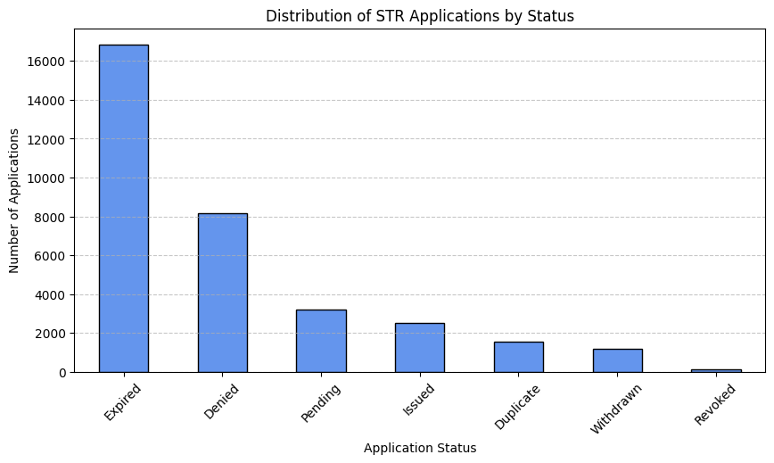

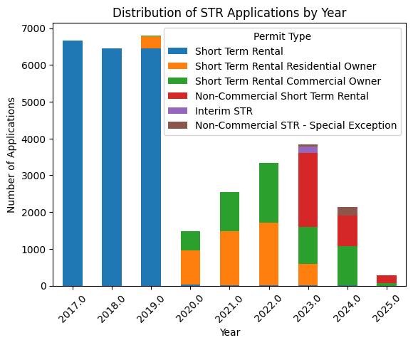

```python
# 1. Bar Chart: Distribution of STR applications by status
plt.figure(figsize=(10,5))
rental_data_full['Current Status'].value_counts().plot(kind='bar', color='cornflowerblue', edgecolor='black')
plt.title("Distribution of STR Applications by Status")
plt.xlabel("Application Status")
plt.ylabel("Number of Applications")
plt.xticks(rotation=45)
plt.grid(axis='y', linestyle='--', alpha=0.7)
plt.show()

# 2. Bar Chart: Application "Permit Types" by year
rental_data_full['Application Date'] = pd.to_datetime(rental_data_full['Application Date'])
rental_data_full['Year'] = rental_data_full['Application Date'].dt.year
rental_data_full.groupby('Year')['Permit Type'].value_counts().unstack().plot(kind='bar', stacked=True)
plt.title("Distribution of STR Applications by Year")
plt.xlabel("Year")
plt.ylabel("Number of Applications")
plt.xticks(rotation=45)
plt.legend(title='Permit Type')
```

## **Observations from Exploratory Analysis of STR Data**

We can see that over since the city began regulating STRs in 2017, there have been drastic changes to the types of applications submitted. Let's take a closer look:

- On **April 1, 2017**, all Short Term Rental properties, residential or Commercial, were required to apply for a **"Short Term Rental"** License (https://nola.gov/nola/media/311/STR-Handbook-version-20191203.pdf)
- On **December 1, 2019**, legislation drew a permit distinction between **"STR Residential Owner"** and **"STR Commercial Owner"** licenses. The new ordinance required that the property must be "Owner Occupied" and that there only be 1 STR per block face (https://www.nola.gov/nola/media/City-Planning/Final-2019-STR-Study-with-Maps.pdf)
- On **July 1, 2023**, all residential STR licenses are phased out and replaced with **"Non-Commercial STR"** licences. The "one licence per block" rule is more strictly enforced; in the case of multiple applicants on the same block, a license is distributed by lottery. No new Commercial STR permits are accepted after June 2023 (https://nola.gov/next/short-term-rental-administration/announcements/changes-to-str-laws/)

As the colors change in the bar graph above, it represents the laws changing in the city surrounding the permiting of STRs in 2017, 2019 and 2023. We can see how passing legislation has reduced new license applications. Moving forward, we can infer that current operating STR properties are represented in the data by the following permits: the most recent **Non-Commercial Short Term Rental licences** (that are issued and not expired) and the **Short Term Rental Commercial Owner licenses** (that have not yet expired or been revoked).

We will filter for those active properties in the next section

## 3.2 Police Data

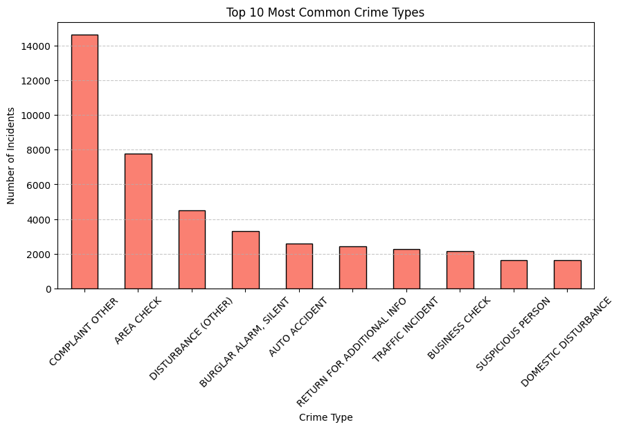

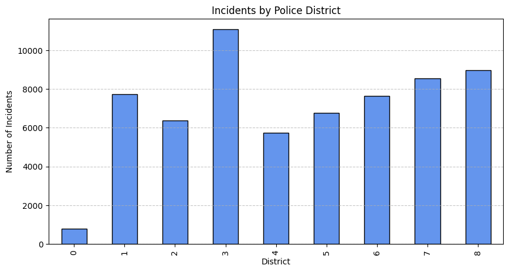

```python
# 1. Bar Chart: Top 10 Most Common Crime Types
plt.figure(figsize=(10,5))
crime_data['TypeText'].value_counts().head(10).plot(kind='bar', color='salmon', edgecolor='black')
plt.title("Top 10 Most Common Crime Types")
plt.xlabel("Crime Type")
plt.ylabel("Number of Incidents")
plt.xticks(rotation=45)
plt.grid(axis='y', linestyle='--', alpha=0.7)
plt.show()

# 3. Bar Chart: Reports by Police District
plt.figure(figsize=(10,5))
crime_data['PoliceDistrict'].value_counts().sort_index().plot(kind='bar', color='cornflowerblue', edgecolor='black')
plt.title("Incidents by Police District")
plt.xlabel("District")
plt.ylabel("Number of Incidents")
plt.grid(axis='y', linestyle='--', alpha=0.7)
plt.show()
```

**Observations from Exploratory Analysis of Police Data**

# 4. Preprocessing

## 4.1 Clean STR Data

Ultimately, our goal with the STR data is to ensure that we are only looking at active STR permits and their location. In order to do that, we want to standardize the fields, parse latitude and logitude from a single point, and remove any incomplete or duplicate entries.

### 4.1.1 Standardize text

```python
# Standardize key text fields
rental_data['Current Status'] = rental_data['Current Status'].str.strip().str.title()
rental_data['Permit Type'] = rental_data['Permit Type'].str.strip().str.title()
rental_data['Address'] = rental_data['Address'].str.strip().str.title()

# Optional fields – check if present
if 'City' in rental_data.columns:
    rental_data['City'] = rental_data['City'].str.strip().str.title()
if 'State' in rental_data.columns:
    rental_data['State'] = rental_data['State'].str.strip().str.upper()

# Check results
print("Unique Current Status values:\n", rental_data['Current Status'].value_counts())
print("\nUnique Permit Types:\n", rental_data['Permit Type'].value_counts())
```

```
Unique Current Status values:
 Current Status
Expired      16837
Denied        8146
Pending       3210
Issued        2511
Duplicate     1545
Withdrawn     1186
Revoked        144
Name: count, dtype: int64

Unique Permit Types:
 Permit Type
Short Term Rental                         19655
Short Term Rental Commercial Owner         5374
Short Term Rental Residential Owner        5025
Non-Commercial Short Term Rental           3063
Non-Commercial Str - Special Exception      285
Interim Str                                 173
Cut Flowers                                   2
O                                             2
Name: count, dtype: int64
```

### 4.1.2 Parse Latitude & Longitude

```python
# Parse from Location string
if 'Location' in rental_data.columns:
    rental_data[['Latitude', 'Longitude']] = (
        rental_data['Location']
        .str.replace('(', '', regex=False)
        .str.replace(')', '', regex=False)
        .str.split(',', expand=True)
        .astype(float)
    )

# Confirm parsing
print("Sample coordinates:")
print(rental_data[['Latitude', 'Longitude']].dropna().head())
```

```
Sample coordinates:
    Latitude   Longitude
0  28.098891 -101.517799
1  28.098891 -101.517799
2  29.935368  -90.073329
3  30.018701  -90.050665
4  28.098891 -101.517799
```

### 4.1.3 Remove Entries Missing Information

```python
before = rental_data.shape[0]
rental_data = rental_data.dropna(subset=['Address', 'Application Date', 'Latitude', 'Longitude'])
after = rental_data.shape[0]
print(f"Removed {before - after} rows missing essential info (address, date, or coords).")
```

```
Removed 319 rows missing essential info (address, date, or coords).
```

### 4.1.4 Remove Bad Coordinates

```python
before = rental_data.shape[0]
rental_data = rental_data[
    (rental_data['Latitude'] > 29.5) & (rental_data['Latitude'] < 30.2) &
    (rental_data['Longitude'] > -90.3) & (rental_data['Longitude'] < -89.8)
]
after = rental_data.shape[0]
print(f"Removed {before - after} rows with out-of-bounds coordinates.")
```

```
Removed 247 rows with out-of-bounds coordinates.
```

### 4.1.5 Filter Out Expired Rows

```python
before = rental_data.shape[0]

# Normalize both fields for safe comparison
status_expired = rental_data['Current Status'].str.lower() == 'expired'
column_expired = rental_data['Expired'].str.lower() == 'yes'

# Filter out rows where either is true
rental_data = rental_data[~(status_expired | column_expired)]

after = rental_data.shape[0]
print(f"Removed {before - after} expired rows (based on 'Current Status' or 'Expired' column).")
print(f"Remaining rows: {after}")
```

```
Removed 29426 expired rows (based on 'Current Status' or 'Expired' column).
Remaining rows: 3587
```

### 4.1.6 Removing Duplicates

```python
# Check for duplicates based on Address + Application Date
before_dedup = rental_data.shape[0]
rental_data = rental_data.drop_duplicates(subset=['Address', 'Application Date'])
after_dedup = rental_data.shape[0]

# Report result
print(f"Duplicates removed: {before_dedup - after_dedup}")
print(f"Remaining rows after deduplication: {after_dedup}")
```

```
Duplicates removed: 36
Remaining rows after deduplication: 3551
```

### 4.1.7 Create filtered subsets (active, non-commercial, etc.)

```python
# 1. Only Clean (remove expired, revoked, withdrawn; duplicates already removed)
clean_statuses = ['Issued', 'Pending', 'Denied']
rental_data_clean = rental_data[rental_data['Current Status'].isin(clean_statuses)].copy()
print(f"Clean rentals: {rental_data_clean.shape[0]}")

# 2. Only Active (Issued only, remove Pending and Denied)
rental_data_active = rental_data[rental_data['Current Status'] == 'Issued'].copy()
print(f"Active rentals: {rental_data_active.shape[0]}")

# 3. Non-Commercial Active Rentals
noncommercial_keywords = ['Non-Commercial']
rental_data_noncommercial_active = rental_data_active[
    rental_data_active['Permit Type'].str.contains('|'.join(noncommercial_keywords), case=False, na=False)
].copy()
print(f"Non-commercial active rentals: {rental_data_noncommercial_active.shape[0]}")

# Optional: Commercial Active Rentals (for contrast)
rental_data_commercial_active = rental_data_active[
    ~rental_data_active['Permit Type'].str.contains('|'.join(noncommercial_keywords), case=False, na=False)
].copy()
print(f"Commercial active rentals: {rental_data_commercial_active.shape[0]}")
```

```
Clean rentals: 3421
Active rentals: 2433
Non-commercial active rentals: 1366
Commercial active rentals: 1067
```

## 4.2 Clean Crime Data

Like the STR data above, we parse the location data so we can eventually merge both data sets over longitutde and latitude. From there, we remove duplicates, bad coordinates, and column data we won't need.

### 4.2.1 Filter & Standardize Crime Types

```python
# View top incident types
print("Top 15 incident types:")
print(crime_data['TypeText'].value_counts().head(15))

# Define administrative or vague types to exclude
excluded_types = [
    'Area Check', 'Complaint Other', 'Traffic Stop', 'Lost/Found Property',
    'Follow Up', 'Special Assignment', 'Administrative Assignment'
]

# Standardize formatting
crime_data['TypeText'] = crime_data['TypeText'].str.strip().str.upper()

# Filter out unwanted types
before = crime_data.shape[0]
crime_data = crime_data[~crime_data['TypeText'].isin([t.upper() for t in excluded_types])]
after = crime_data.shape[0]

print(f"Removed {before - after} administrative/cruft records. Remaining: {after}")
print("Remaining unique crime types:", crime_data['TypeText'].nunique())
```

```
Top 15 incident types:
TypeText
COMPLAINT OTHER               14641
AREA CHECK                     7778
DISTURBANCE (OTHER)            4510
BURGLAR ALARM, SILENT          3322
AUTO ACCIDENT                  2602
RETURN FOR ADDITIONAL INFO     2445
TRAFFIC INCIDENT               2278
BUSINESS CHECK                 2132
SUSPICIOUS PERSON              1634
DOMESTIC DISTURBANCE           1609
HIT & RUN                      1377
MEDICAL                        1069
MENTAL PATIENT                 1017
THEFT                           914
TRAFFIC STOP                    819
Name: count, dtype: int64
Removed 23238 administrative/cruft records. Remaining: 40458
Remaining unique crime types: 178
```

### 4.2.2 Define Crime Categories

```python
# Define crime categories based on common crime types
violent_crimes = ['AGGRAVATED BATTERY', 'HOMICIDE', 'ASSAULT', 'ARMED ROBBERY', 'SHOOTING', 'SEXUAL ASSAULT']
property_crimes = ['THEFT', 'BURGLARY', 'AUTO THEFT', 'SHOPLIFTING', 'PROPERTY DAMAGE', 'FRAUD']

# Add a new categorical column
crime_data['CrimeCategory'] = crime_data['TypeText'].apply(
    lambda x: 'Violent' if x.upper() in violent_crimes
    else ('Property' if x.upper() in property_crimes else 'Other')
)



# Check results
print(crime_data['CrimeCategory'].value_counts())
```

```
CrimeCategory
Other       38400
Property     1997
Violent        61
Name: count, dtype: int64
```

### 4.2.3 Parse Latitude & Longitude

```python
# Parse Latitude and Longitude from 'Location' column (format: 'POINT (long lat)')
crime_data[['Longitude', 'Latitude']] = (
    crime_data['Location']
    .str.extract(r'POINT \((-?\d+\.\d+) (-?\d+\.\d+)\)')
    .astype(float)
)

# Check parsing results
print("Parsed coordinates. Sample rows:")
print(crime_data[['Location', 'Latitude', 'Longitude']].dropna().head())
```

```
Parsed coordinates. Sample rows:
                           Location   Latitude  Longitude
0  POINT (-90.07669075 29.94962691)  29.949627 -90.076691
1  POINT (-90.08040385 29.96548237)  29.965482 -90.080404
2  POINT (-89.98236714 30.04579172)  30.045792 -89.982367
3    POINT (-90.004185 30.03584305)  30.035843 -90.004185
6  POINT (-90.05384273 30.01687511)  30.016875 -90.053843
```

### 4.2.4 Remove Invalid Coordinates

```python
# Filter out rows with missing or clearly invalid coordinates
before = crime_data.shape[0]

crime_data = crime_data.dropna(subset=['Latitude', 'Longitude'])
crime_data = crime_data[
    (crime_data['Latitude'] > 29.5) & (crime_data['Latitude'] < 30.2) &
    (crime_data['Longitude'] > -90.3) & (crime_data['Longitude'] < -89.8)
]

after = crime_data.shape[0]
print(f"Removed {before - after} rows with invalid or out-of-bounds coordinates.")
print(f"Remaining rows: {after}")
```

```
Removed 3183 rows with invalid or out-of-bounds coordinates.
Remaining rows: 37275
```

### 4.2.5 Remove Duplicates

```python
# Drop spatial-temporal duplicates
before = crime_data.shape[0]
crime_data = crime_data.drop_duplicates(subset=['Longitude', 'Latitude', 'TimeCreate'])
after = crime_data.shape[0]

print(f"Removed {before - after} duplicate spatial-time rows.")
```

```
Removed 0 duplicate spatial-time rows.
```

### 4.2.6 Drop Unused Columns

```python
# Drop irrelevant columns for merging/analysis
columns_to_drop = [
    'MapX', 'MapY', 'TimeDispatch', 'TimeArrive', 'TimeClosed',
    'InitialType', 'InitialTypeText', 'InitialPriority',
    'Disposition', 'DispositionText', 'SelfInitiated',
    'Beat', 'BLOCK_ADDRESS', 'Zip'
]

crime_data = crime_data.drop(columns=[col for col in columns_to_drop if col in crime_data.columns])

print(f"Columns after cleanup: {list(crime_data.columns)}")
```

```
Columns after cleanup: ['NOPD_Item', 'Type', 'TypeText', 'Priority', 'TimeCreate', 'PoliceDistrict', 'Location', 'CrimeCategory', 'Longitude', 'Latitude']
```

# 5. Merge

Now that the data is cleaned, we want a way to merge the STR data and the crime data. We are trying to see the relationship between geographical-specific crime and STR density, so we will link our data by location. We define a "bin" by rounding latitude and longitude to 2 decimal places (about 1 sq. km) and aggregating crime values that fall in the bucket. We also want split violent crime and property crime to see if theres a distinction.

## 5.1 Using 2-Decimal Precision (about *1km* bins)

```python
# Step 1: Generate coord_key_p2 in crime_data
crime_data['lat_round_p2'] = crime_data['Latitude'].round(2)
crime_data['lon_round_p2'] = crime_data['Longitude'].round(2)
crime_data['coord_key_p2'] = crime_data['lat_round_p2'].astype(str) + "_" + crime_data['lon_round_p2'].astype(str)

# Step 2: Generate coord_key_p2 in STR datasets
for name, df in [
    ('rental_data_active', rental_data_active),
    ('rental_data_noncommercial_active', rental_data_noncommercial_active),
    ('rental_data_commercial_active', rental_data_commercial_active)
]:
    df['lat_round_p2'] = df['Latitude'].round(2)
    df['lon_round_p2'] = df['Longitude'].round(2)
    df['coord_key_p2'] = df['lat_round_p2'].astype(str) + "_" + df['lon_round_p2'].astype(str)
    globals()[name] = df

print("coord_key_p2 added to all datasets.")

# Step 3a: Aggregate by TypeText (for individual crime types)
crime_by_type_p2 = (
    crime_data
    .groupby(['coord_key_p2', 'TypeText'])
    .size()
    .unstack(fill_value=0)
    .reset_index()
)

crime_by_type_p2['total_crimes'] = crime_by_type_p2.drop(columns='coord_key_p2').sum(axis=1)
print("Created crime_by_type_p2 with shape:", crime_by_type_p2.shape)

# Step 3b: Aggregate by CrimeCategory for modeling
crime_by_cat_p2 = (
    crime_data
    .groupby(['coord_key_p2', 'CrimeCategory'])
    .size()
    .unstack(fill_value=0)
    .reset_index()
)

crime_by_cat_p2 = crime_by_cat_p2.rename(columns={
    'Violent': 'violent_crime_count',
    'Property': 'property_crime_count'
})
crime_by_cat_p2['crime_count'] = (
    crime_by_cat_p2.get('violent_crime_count', 0) +
    crime_by_cat_p2.get('property_crime_count', 0)
)

# Step 4: Merge both crime summaries into STR datasets
for name in ['rental_data_active', 'rental_data_noncommercial_active', 'rental_data_commercial_active']:
    df = globals()[name]

    # Merge by TypeText
    df = df.merge(crime_by_type_p2, on='coord_key_p2', how='left')

    # Merge by Category
    df = df.merge(crime_by_cat_p2, on='coord_key_p2', how='left')

    # Fill NaNs
    for col in ['violent_crime_count', 'property_crime_count', 'crime_count']:
        if col not in df.columns:
            df[col] = 0
        else:
            df[col] = df[col].fillna(0)

    globals()[name] = df
    print(f"Merged crime data (2-dec precision) onto {name}. New shape: {df.shape}")
```

```
coord_key_p2 added to all datasets.
Created crime_by_type_p2 with shape: (283, 155)
Merged crime data (2-dec precision) onto rental_data_active. New shape: (2433, 184)
Merged crime data (2-dec precision) onto rental_data_noncommercial_active. New shape: (1366, 184)
Merged crime data (2-dec precision) onto rental_data_commercial_active. New shape: (1067, 184)
```

## 5.2 Using 3-Decimal Precision (about *100m* bins)

```python
# Step 1: Generate coord_key_p3 in crime_data
crime_data['lat_round_p3'] = crime_data['Latitude'].round(3)
crime_data['lon_round_p3'] = crime_data['Longitude'].round(3)
crime_data['coord_key_p3'] = crime_data['lat_round_p3'].astype(str) + "_" + crime_data['lon_round_p3'].astype(str)

# Step 2: Generate coord_key_p3 in STR datasets
for name, df in [
    ('rental_data_active', rental_data_active),
    ('rental_data_noncommercial_active', rental_data_noncommercial_active),
    ('rental_data_commercial_active', rental_data_commercial_active)
]:
    df['lat_round_p3'] = df['Latitude'].round(3)
    df['lon_round_p3'] = df['Longitude'].round(3)
    df['coord_key_p3'] = df['lat_round_p3'].astype(str) + "_" + df['lon_round_p3'].astype(str)
    globals()[name] = df

print("coord_key_p3 added to crime and STR datasets.")

# Step 3: Aggregate crime counts by coord_key_p3 and TypeText
crime_by_type_p3 = (
    crime_data
    .groupby(['coord_key_p3', 'TypeText'])
    .size()
    .unstack(fill_value=0)
    .reset_index()
)

# Add total crime counts
crime_by_type_p3['total_crimes'] = crime_by_type_p3.drop(columns='coord_key_p3').sum(axis=1)
print(f"crime_by_type_p3 created. Shape: {crime_by_type_p3.shape}")

# Step 4: Merge aggregated crime data onto STR datasets
for name in ['rental_data_active', 'rental_data_noncommercial_active', 'rental_data_commercial_active']:
    df = globals()[name]
    merged_df = df.merge(crime_by_type_p3, on='coord_key_p3', how='left')
    globals()[name] = merged_df
    print(f"Merged crime data (3-dec precision) onto {name}. New shape: {merged_df.shape}")
```

```
coord_key_p3 added to crime and STR datasets.
crime_by_type_p3 created. Shape: (8104, 155)
Merged crime data (3-dec precision) onto rental_data_active. New shape: (2433, 341)
Merged crime data (3-dec precision) onto rental_data_noncommercial_active. New shape: (1366, 341)
Merged crime data (3-dec precision) onto rental_data_commercial_active. New shape: (1067, 341)
```

# 6. Visualization & Mapping

## 6.1 Folium map: STRs on the Same Block

The most current law in 2023 allows the city to grant only Non-Commercial STR permits (red below) in an attempt to reduce commercial operators from buying property and converting it into short term rentals. Ultimately the move aims to reduce competition for housing for New Orleanians. While Commercial STR ( green below) permits are set to expire later this year, currently there are active commercial permits.

The law also states that only one STR can operate per block. In New Orleans, every block resets the address numbers at the next multiple of 100 (regardless of how many addresses are actualy used). Therefore, if any current, issued permit addresses have the same hundreds digit (but different addresses), we can assume that the properties are on the same block. Let's do a quick check to see if we can find any permits that were issued on the same block:

```python
from folium.plugins import MarkerCluster
from branca.element import Template, MacroElement

# Step 1: Function to extract block ID from address
def extract_block(address):
    parts = str(address).split()
    if parts and parts[0].isdigit():
        block_number = int(parts[0])
        block = (block_number // 100) * 100  # e.g., 1234 → 1200
        street_name = ' '.join(parts[1:])
        return f"{block} {street_name}".lower()
    return None

# Apply to rental_data_active
rental_data_active['block_id'] = rental_data_active['Address'].apply(extract_block)

# Step 2: Identify shared blocks
block_counts = rental_data_active['block_id'].value_counts()
duplicate_blocks = block_counts[block_counts > 1].index
STR_shared_block = rental_data_active[rental_data_active['block_id'].isin(duplicate_blocks)]

# Step 3: Initialize base map
map_nola = folium.Map(location=[29.95, -90.07], zoom_start=12, tiles='cartodbpositron')

# Helper function to add markers by category
def add_marker(df, color, folium_map, popup_col='Permit Type'):
    for _, row in df.iterrows():
        folium.CircleMarker(
            location=[row['Latitude'], row['Longitude']],
            radius=3,
            color=color,
            fill=True,
            fill_opacity=0.7,
            popup=row.get(popup_col, 'STR')
        ).add_to(folium_map)

# Step 4: Add markers for non-commercial (red), commercial (green), and shared-block (orange)
add_marker(rental_data_noncommercial_active, 'red', map_nola)
add_marker(rental_data_commercial_active, 'green', map_nola)
add_marker(STR_shared_block, 'orange', map_nola)

# Step 5: Add custom legend
legend_html = """
{% macro html(this, kwargs) %}
<div style="
    position: fixed;
    bottom: 50px; left: 50px; width: 180px; height: 130px;
    border:2px solid grey; z-index:9999; font-size:14px;
    background-color: white;
    padding: 10px;
    ">
    <b>Legend</b><br>
    <i style="background:red; border-radius:50%; width:10px; height:10px; display:inline-block;"></i> Non-Commercial STR<br>
    <i style="background:green; border-radius:50%; width:10px; height:10px; display:inline-block;"></i> Commercial STR<br>
    <i style="background:orange; border-radius:50%; width:10px; height:10px; display:inline-block;"></i> Shared Block STR<br>
</div>
{% endmacro %}
"""
legend = MacroElement()
legend._template = Template(legend_html)
map_nola.get_root().add_child(legend)

# Display the map
display(map_nola)
```

```
Output hidden; open in https://colab.research.google.com to view.
```

## 6.2 STR Density vs Property Crime

Now that we have both STRs and Property Crime filtered by location and put into ~1 sq. km bins, we want to see the relationship between our data, specifically the correlation.

Below we will analyze the relationship between Non-Comercial/ Commercial permit types, vs property crime/ violent crime

```
Correlation between STR Density and Property Crime Count for Active STRs: 0.749
Correlation between STR Density and Property Crime Count for Commercial STRs: 0.819
Correlation between STR Density and Property Crime Count for Non-Commercial STRs: 0.357
```

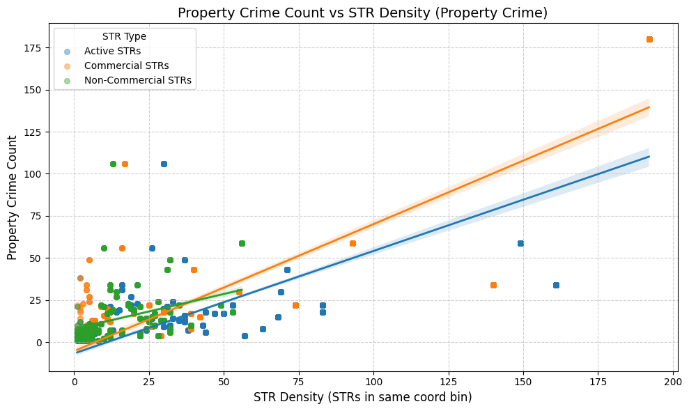

```python
# Prepare datasets and labels
datasets = [
    (rental_data_active.copy(), "Active STRs"),
    (rental_data_commercial_active.copy(), "Commercial STRs"),
    (rental_data_noncommercial_active.copy(), "Non-Commercial STRs")
]

# Choose which crime metric to visualize
crime_col = 'property_crime_count'  # or 'violent_crime_count'
coord_col = 'coord_key_p2'
title_suffix = '(Property Crime)'

plt.figure(figsize=(10, 6))

# Loop through each dataset, compute correlation, and plot
for df, label in datasets:
    df['str_count'] = df.groupby(coord_col)[coord_col].transform('count')

    if crime_col not in df.columns:
        print(f"{crime_col} not found in {label}")
        continue

    plot_df = df[[crime_col, 'str_count']].dropna()
    plot_df = plot_df[(plot_df['str_count'] > 0) & (plot_df[crime_col] > 0)]

    # Print correlation
    corr = plot_df[['str_count', crime_col]].corr().iloc[0, 1]
    print(f"Correlation between STR Density and {crime_col.replace('_', ' ').title()} for {label}: {corr:.3f}")

    # Plot regression line with scatter
    sns.regplot(
        data=plot_df,
        x='str_count',
        y=crime_col,
        label=label,
        scatter_kws={'alpha': 0.4, 's': 30},
        line_kws={'linewidth': 2}
    )

# Final plot formatting
plt.title(f'{crime_col.replace("_", " ").title()} vs STR Density {title_suffix}', fontsize=14)
plt.xlabel('STR Density (STRs in same coord bin)', fontsize=12)
plt.ylabel(crime_col.replace("_", " ").title(), fontsize=12)
plt.grid(True, linestyle='--', alpha=0.6)
plt.legend(title='STR Type')
plt.tight_layout()
plt.show()
```

## 6.3 STR Density vs Violent Crime

```
Correlation between STR Density and Violent Crime Count for Active STRs: -0.179
Correlation between STR Density and Violent Crime Count for Commercial STRs: -0.143
Correlation between STR Density and Violent Crime Count for Non-Commercial STRs: -0.273
```

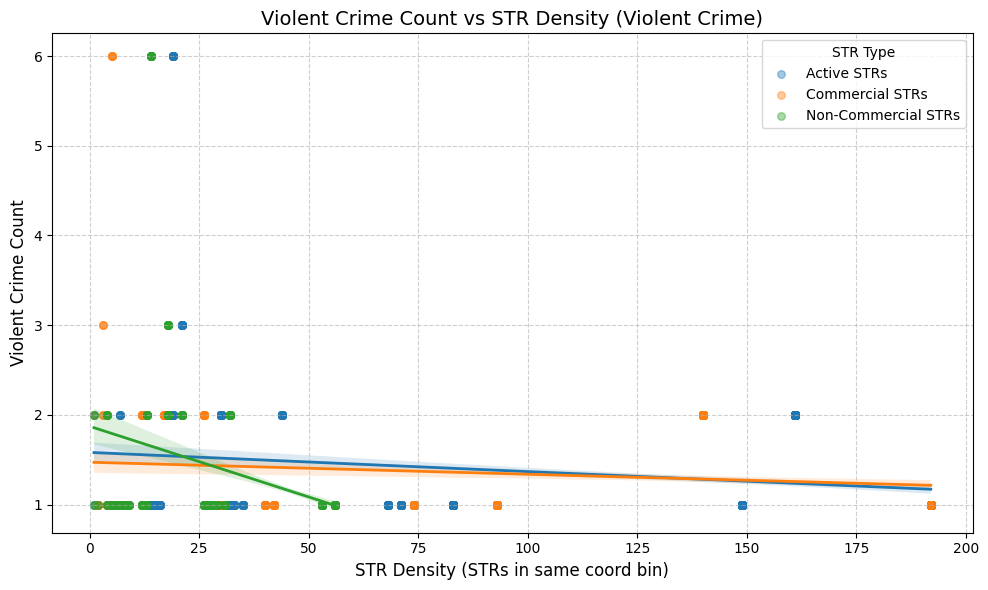

```python
# Violent Crime Plot
datasets = [
    (rental_data_active.copy(), "Active STRs"),
    (rental_data_commercial_active.copy(), "Commercial STRs"),
    (rental_data_noncommercial_active.copy(), "Non-Commercial STRs")
]

crime_col = 'violent_crime_count'
coord_col = 'coord_key_p2'
title_suffix = '(Violent Crime)'

plt.figure(figsize=(10, 6))

for df, label in datasets:
    df['str_count'] = df.groupby(coord_col)[coord_col].transform('count')
    if crime_col not in df.columns:
        print(f"{crime_col} not found in {label}")
        continue
    plot_df = df[[crime_col, 'str_count']].dropna()
    plot_df = plot_df[(plot_df['str_count'] > 0) & (plot_df[crime_col] > 0)]

    corr = plot_df[['str_count', crime_col]].corr().iloc[0, 1]
    print(f"Correlation between STR Density and {crime_col.replace('_', ' ').title()} for {label}: {corr:.3f}")

    sns.regplot(
        data=plot_df,
        x='str_count',
        y=crime_col,
        label=label,
        scatter_kws={'alpha': 0.4, 's': 30},
        line_kws={'linewidth': 2}
    )

plt.title(f'{crime_col.replace("_", " ").title()} vs STR Density {title_suffix}', fontsize=14)
plt.xlabel('STR Density (STRs in same coord bin)', fontsize=12)
plt.ylabel(crime_col.replace("_", " ").title(), fontsize=12)
plt.grid(True, linestyle='--', alpha=0.6)
plt.legend(title='STR Type')
plt.tight_layout()
plt.show()
```

# 7. Normalization of STR features

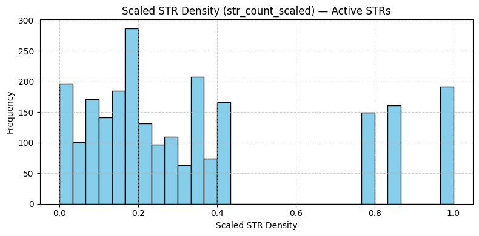

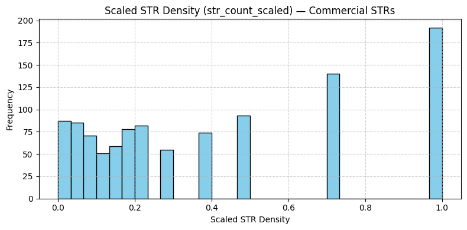

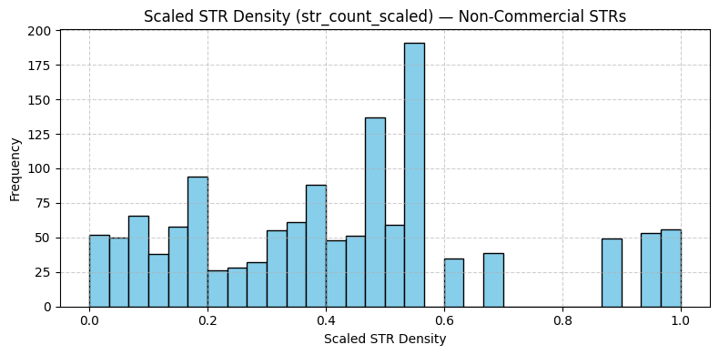

```python
from sklearn.preprocessing import MinMaxScaler
# Step 7.1: Add STR density if missing
for df in [rental_data_active, rental_data_commercial_active, rental_data_noncommercial_active]:
    if 'str_count' not in df.columns:
        df['str_count'] = df.groupby('coord_key_p2')['coord_key_p2'].transform('count')

# Step 7.2–3: Normalize selected features
features_to_scale = ['str_count', 'property_crime_count', 'violent_crime_count']
scaler = MinMaxScaler()

def normalize_and_preview(df, label):
    df_scaled = df.copy()
    df_scaled[features_to_scale] = df_scaled[features_to_scale].fillna(0)
    scaled_columns = [f"{col}_scaled" for col in features_to_scale]
    df_scaled[scaled_columns] = scaler.fit_transform(df_scaled[features_to_scale])

    # Preview one scaled feature
    plt.figure(figsize=(8, 4))
    plt.hist(df_scaled['str_count_scaled'], bins=30, color='skyblue', edgecolor='black')
    plt.title(f'Scaled STR Density (str_count_scaled) — {label}')
    plt.xlabel('Scaled STR Density')
    plt.ylabel('Frequency')
    plt.grid(True, linestyle='--', alpha=0.6)
    plt.tight_layout()
    plt.show()

    return df_scaled

# Step 7.4: Apply to each dataset
rental_data_active_scaled = normalize_and_preview(rental_data_active, "Active STRs")
rental_data_commercial_active_scaled = normalize_and_preview(rental_data_commercial_active, "Commercial STRs")
rental_data_noncommercial_active_scaled = normalize_and_preview(rental_data_noncommercial_active, "Non-Commercial STRs")
```

# 8. Hypothesis

We hypothesize that higher densities of Short-Term Rentals (STRs), particularly **commercial STRs**, are positively correlated with **higher property crime rates** in New Orleans.

To test this hypothesis, we developed a classification model using STR density and STR type (commercial vs non-commercial) to predict whether a given location experiences high property crime.

Our expectation was that these simple spatial features would be predictive of high-crime areas — and our results support that claim.

# 9. Modeling

## 9.1 Define Modeling Objective

We will use a classification model to predict whether a short-term rental (STR) location falls into a high property crime area.

- **Model type**: K-Nearest Neighbors (KNN)
- **Target**: `high_crime` — a binary label indicating high property crime
- **Threshold**: Top 25% (property_crime_count > 34)
- **Focus**: Only on `rental_data_active_scaled` for initial modeling
- **Features**: Scaled STR density (`str_count_scaled`) and optionally STR type

## 9.2 Create Target Variable

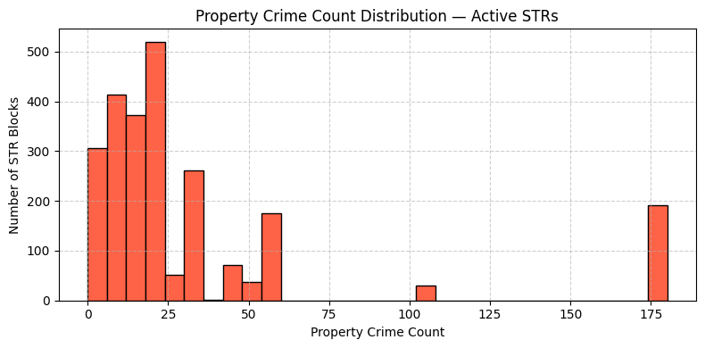

```
Active STRs — Property Crime Summary:
count    2433.000000
mean       34.228113
std        46.144503
min         0.000000
25%         9.000000
50%        18.000000
75%        34.000000
max       180.000000
Name: property_crime_count, dtype: float64
```

```python
# Explore distribution of property crime count
def explore_property_crime_distribution(df, label):
    df = df.copy()
    df['property_crime_count'] = df['property_crime_count'].fillna(0)

    # Histogram
    plt.figure(figsize=(8, 4))
    plt.hist(df['property_crime_count'], bins=30, color='tomato', edgecolor='black')
    plt.title(f'Property Crime Count Distribution — {label}')
    plt.xlabel('Property Crime Count')
    plt.ylabel('Number of STR Blocks')
    plt.grid(True, linestyle='--', alpha=0.6)
    plt.tight_layout()
    plt.show()

    # Summary statistics
    desc = df['property_crime_count'].describe()
    print(f"{label} — Property Crime Summary:")
    print(desc)

# Run for rental_data_active
explore_property_crime_distribution(rental_data_active, "Active STRs")
```

We define a new binary column `high_crime` in the `rental_data_active_scaled` dataset:

- `1` if `property_crime_count > 34` (75th percentile)
- `0` otherwise

This serves as the target for our classification model.

```python
# Create binary target variable based on 75th percentile threshold
crime_threshold = 34  # from previous analysis

# Add binary target column
rental_data_active_scaled = rental_data_active_scaled.copy()
rental_data_active_scaled['high_crime'] = (rental_data_active_scaled['property_crime_count'] > crime_threshold).astype(int)

# Check result
print("High crime label distribution:")
print(rental_data_active_scaled['high_crime'].value_counts())
rental_data_active_scaled[['property_crime_count', 'high_crime']].head()
```

```
High crime label distribution:
high_crime
0    1926
1     507
Name: count, dtype: int64
```

|  | property_crime_count | high_crime |
| --- | --- | --- |
| 0 | 180 | 1 |
| 1 | 34 | 0 |
| 2 | 59 | 1 |
| 3 | 12 | 0 |
| 4 | 56 | 1 |

## 9.3 Feature Preparation

We select `str_count_scaled` as the primary feature for modeling, since this reflects STR density in a normalized format.

Optionally, we add a binary indicator `is_commercial` to represent STR type. This can help the model differentiate between commercial and non-commercial STRs.

- **Features (X)**:
  - `str_count_scaled`
  - `is_commercial` (0 = non-commercial, 1 = commercial)
- **Target (y)**:
  - `high_crime`

```python
# Add a binary indicator for STR type
# Assume commercial = any STR not containing 'non-commercial'
rental_data_active_scaled['is_commercial'] = ~rental_data_active_scaled['Permit Type'].str.contains('non-commercial', case=False, na=False)
rental_data_active_scaled['is_commercial'] = rental_data_active_scaled['is_commercial'].astype(int)

# Select features and target
X = rental_data_active_scaled[['str_count_scaled', 'is_commercial']]
y = rental_data_active_scaled['high_crime']

# Preview
print("Feature matrix (X):")
print(X.head())
print("\nTarget vector (y):")
print(y.value_counts())
```

```
Feature matrix (X):
   str_count_scaled  is_commercial
0          1.000000              1
1          0.837696              1
2          0.774869              0
3          0.188482              0
4          0.130890              1

Target vector (y):
high_crime
0    1926
1     507
Name: count, dtype: int64
```

## 9.4 Train/Test Split

We split the dataset into training and test sets using an 80/20 split.

- Stratified sampling is used to preserve the class distribution of `high_crime`
- This ensures the model trains and is evaluated on a representative balance of high/low crime locations

```python
# ✅ 80/20 split with stratification on the target
X_train, X_test, y_train, y_test = train_test_split(
    X,
    y,
    test_size=0.2,
    random_state=42,
    stratify=y  # preserves class distribution
)

# Confirm shapes and class balance
print(f"Training set size: {X_train.shape[0]}")
print(f"Test set size: {X_test.shape[0]}")
print("\nTarget distribution in train:")
print(y_train.value_counts(normalize=True))
print("\nTarget distribution in test:")
print(y_test.value_counts(normalize=True))
```

```
Training set size: 1946
Test set size: 487

Target distribution in train:
high_crime
0    0.791367
1    0.208633
Name: proportion, dtype: float64

Target distribution in test:
high_crime
0    0.792608
1    0.207392
Name: proportion, dtype: float64
```

## 9.5 Train the KNN Classifier

### 9.5.1 Tune K

To determine the optimal value of `K` for our KNN classifier, we test a range of values (1 to 20) and evaluate the model's accuracy on the test set.

This helps us avoid underfitting or overfitting and select a K that best balances model complexity and generalization.

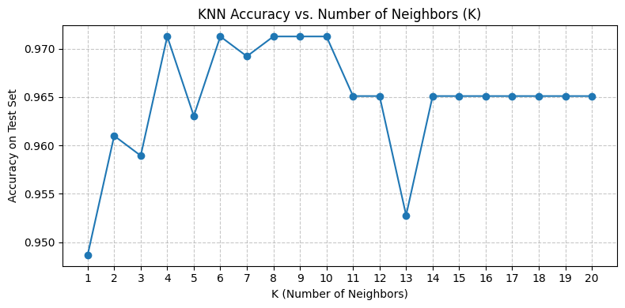

```
Best K based on accuracy: 4
```

```python
from sklearn.neighbors import KNeighborsClassifier
from sklearn.metrics import accuracy_score
import matplotlib.pyplot as plt

# Try K from 1 to 20
k_values = list(range(1, 21))
accuracies = []

for k in k_values:
    knn = KNeighborsClassifier(n_neighbors=k)
    knn.fit(X_train, y_train)
    y_pred = knn.predict(X_test)
    acc = accuracy_score(y_test, y_pred)
    accuracies.append(acc)

# Plot K vs Accuracy
plt.figure(figsize=(8, 4))
plt.plot(k_values, accuracies, marker='o')
plt.title('KNN Accuracy vs. Number of Neighbors (K)')
plt.xlabel('K (Number of Neighbors)')
plt.ylabel('Accuracy on Test Set')
plt.xticks(k_values)
plt.grid(True, linestyle='--', alpha=0.7)
plt.tight_layout()
plt.show()

# Report best K
best_k = k_values[accuracies.index(max(accuracies))]
print(f"Best K based on accuracy: {best_k}")
```

### 9.5.2 Train Final KNN Model

Using the optimal number of neighbors (`K = 4`), we train a K-Nearest Neighbors classifier on our scaled features (`str_count_scaled`, `is_commercial`) to predict whether a location is high-crime.

We then evaluate the model on the test set.

```python
from sklearn.neighbors import KNeighborsClassifier
from sklearn.metrics import classification_report, confusion_matrix

# Train final KNN model with K=4
final_knn = KNeighborsClassifier(n_neighbors=4)
final_knn.fit(X_train, y_train)

# Predict on test set
y_pred = final_knn.predict(X_test)

# Evaluate
print("Confusion Matrix:")
print(confusion_matrix(y_test, y_pred))

print("\nClassification Report:")
print(classification_report(y_test, y_pred, target_names=["Low Crime", "High Crime"]))
```

```
Confusion Matrix:
[[385   1]
 [ 13  88]]

Classification Report:
              precision    recall  f1-score   support

   Low Crime       0.97      1.00      0.98       386
  High Crime       0.99      0.87      0.93       101

    accuracy                           0.97       487
   macro avg       0.98      0.93      0.95       487
weighted avg       0.97      0.97      0.97       487
```

# 10. Conclusion

In this project, we explored the relationship between Short-Term Rental (STR) density and crime levels across New Orleans. By merging STR permit data with police incident reports, we engineered spatial features (via coordinate rounding) to allow meaningful comparisons at both neighborhood and street-block levels.

Through our exploratory analysis and mapping, we identified that STR density—especially commercial STRs—tends to be more concentrated in areas with higher crime levels, particularly property crime. Violent crime, however, showed little to no correlation with STR presence.

We normalized features and trained a K-Nearest Neighbors (KNN) classifier to predict whether a given location would be classified as "high-crime." With only two features (`str_count_scaled` and `is_commercial`), our final model achieved:

- **97% overall accuracy**
- **99% precision** and **87% recall** for high-crime predictions
- Strong performance despite modest class imbalance (~21% high-crime zones)

## 10.2 Limitations and Future Work

- Our model does not include time-based features or account for seasonality in crime
- Incorporating neighborhood demographics or zoning data could enhance predictive power
- Future iterations might include ensemble methods or try spatial clustering (e.g., DBSCAN) for unsupervised insights

## 10.3 Takeaway

Data science can illuminate spatial-social patterns that aren't always obvious. Our work shows that STR regulation may need to consider not just location, but density thresholds, especially in high-crime, high-STR corridors of the city.

```python
%%shell
# Convert the final notebook to HTML for GitHub Pages
# Convert notebook to HTML
jupyter nbconvert --to html "/content/drive/MyDrive/Colab Notebooks/Milestone 3.ipynb"
```

```
[NbConvertApp] Converting notebook /content/drive/MyDrive/Colab Notebooks/Milestone 3.ipynb to html
[NbConvertApp] WARNING | Alternative text is missing on 11 image(s).
[NbConvertApp] Writing 1188253 bytes to /content/drive/MyDrive/Colab Notebooks/Milestone 3.html
```